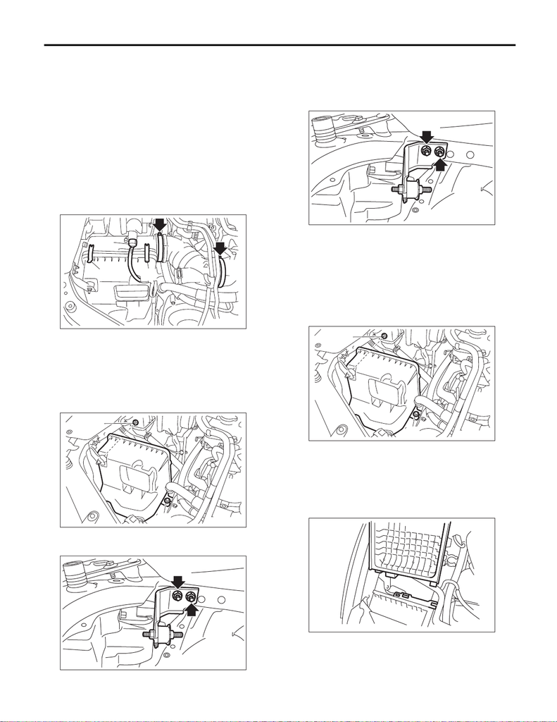

IN(STI)-9

Air Cleaner Case

INTAKE (INDUCTION)

3. Air Cleaner Case

A: REMOVAL

1) Disconnect the ground cable from battery.

2) Remove the air intake duct. <Ref. to IN(STI)-11,

REMOVAL, Air Intake Duct.>

3) Remove the chamber assembly. <Ref. to

IN(STI)-22, REMOVAL, Chamber Assembly.>

4) Disconnect the connector (A) from air flow and

intake air temperature sensor.

5) Loosen the clamp (B) which holds the air intake

boot.

6) Remove the clip (C) from the air cleaner case

(front).

7) Remove the air cleaner case (rear) and air in-

take boot.

8) Remove the air cleaner element.

9) Remove bolts (A) and nuts (B) which secure the

air cleaner case (front) to the body and air cleaner

case bracket, and remove the air cleaner case

(front).

10) Remove the air cleaner case bracket from the

vehicle.

B: INSTALLATION

1) Install the air cleaner case bracket to the vehicle.

Tightening torque:

7.5 N·m (0.8 kgf-m, 5.5 ft-lb)

2) Install the bolt (A) and nut (B) which secure the

air cleaner case (front) to the vehicle and to the air

cleaner case bracket.

Tightening torque:

Bolt (A)

6 N·m (0.6 kgf-m, 4.4 ft-lb)

Nut (B)

7.5 N·m (0.8 kgf-m, 5.5 ft-lb)

3) Set the air cleaner element and air cleaner case

(rear) to the air cleaner case (front).

NOTE:

When setting the air cleaner case (rear), align the

protrusion of the air cleaner case (rear) to the air

cleaner case (front) to insert.

IN-03648

(C)

(C)

(A)

(B)

(B)

IN-03562

(A)

(B)

IN-03591

IN-03591

IN-03562

(A)

(B)

IN-02376

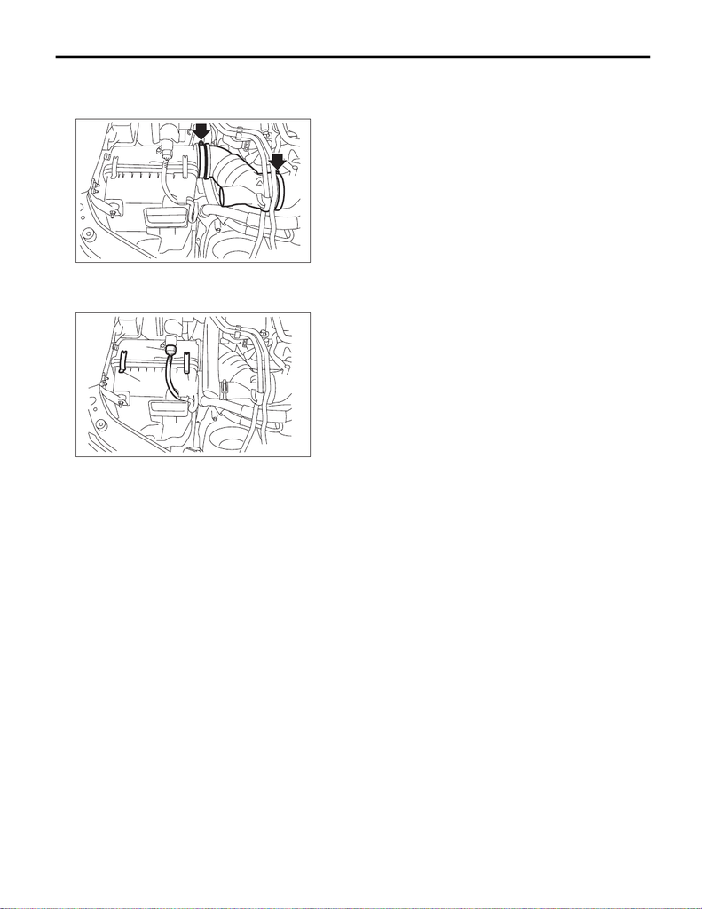

IN(STI)-10

Air Cleaner Case

INTAKE (INDUCTION)

4) Install the air intake boot.

Tightening torque:

2.5 N·m (0.3 kgf-m, 1.8 ft-lb)

5) Install the clip (B) to the air cleaner case (front).

6) Connect the connector (A) to the mass air flow

and intake air temperature sensor.

7) Install the chamber assembly. <Ref. to IN(STI)-

22, INSTALLATION, Chamber Assembly.>

8) Install the air intake duct. <Ref. to IN(STI)-11, IN-

STALLATION, Air Intake Duct.>

9) Connect the battery ground terminal.

C: INSPECTION

1) Check that the air cleaner case has no deforma-

tion, cracks or other damages.

2) Check that the air intake boot has no cracks,

damage or loose part.

IN-03564

IN-03559

(A)

(B)

(B)